# Take Home Midterm

Patrick Burke

3/9/2022

## Section 1 - Data Visualization

### Introduction

Visualizing Data has become an essential part of media and storytelling as technology has improve. News stories use plots to represent the story, companies create graphs to illustrate trends, data visualization has become an essential part of explaining complex problems through concise, understandable imagery. Although these visualizations are swift methods to tell a visual story, it is key to look at plots with scrutiny, as there are aspects of data visualization which can be skewed and twisted to promote a certain idea or hypothesis. As we review the essentials of data visualization, we will analyze the important ethical aspects of representing data, along with the different techniques to make eye-catching representations.

### Grammar of Graphics

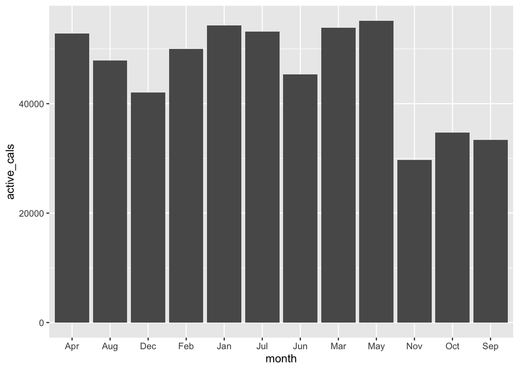

```r
ggplot(data = fitness_df, aes(x = month, y = active_cals)) +
  geom_col()
```

- `<DATA>`: the data set
  - Simply the data that is used in the plot. It is the data that is being visualized, seen above as the first argument in `ggplot()`
- `<MAPPINGS>`: an aesthetic mapping
  - The (x, y) positioning, and customization features such as color, fill, shape, and group.
  - One thing we could map onto this graph is a categorical variable to color the bars by. This is done with the `fill` argument of `<MAPPING>`, and setting it to a variable.

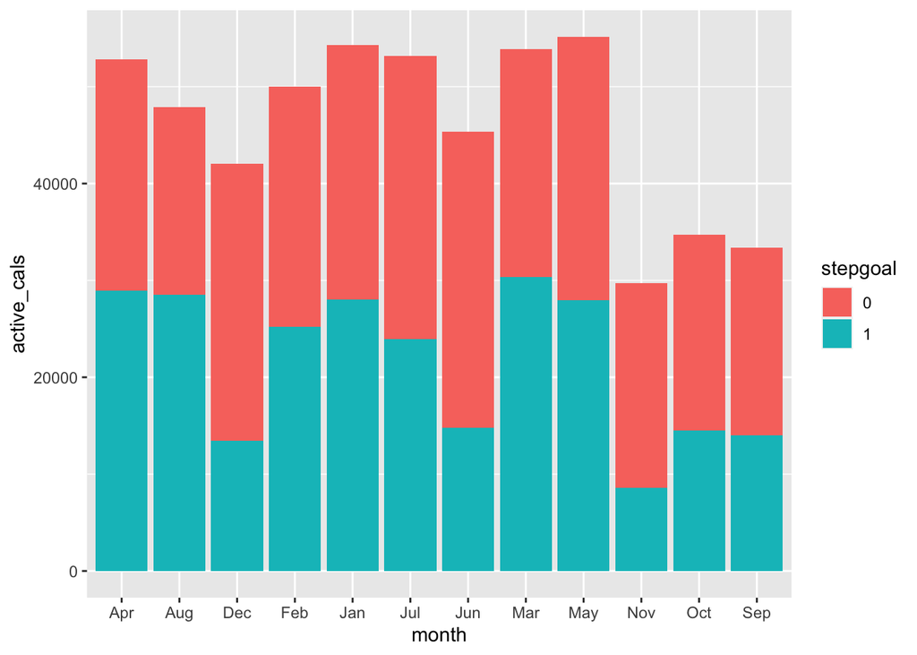

```r
ggplot(data = fitness_df, aes(x = month, y = active_cals)) +
  geom_col(aes(fill = stepgoal))
```

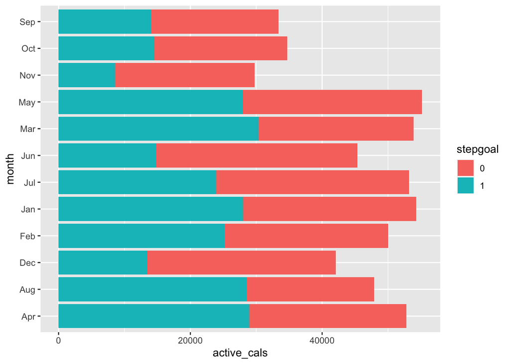

```r
ggplot(data = fitness_df, aes(x = month, y = active_cals)) +
  geom_col(aes(fill = stepgoal)) +
  coord_flip()
```

- `<STAT>`: a statistical transformation
  - The transformation being applied to the geometric object. For example, a histogram could have a `<STAT>` value of density or count, whichever the user clarifies.
- `<POSITION>`: a position adjustment
  - With `<POSITION>` you can change the placement of certain objects in a graph.
  - For example, a stacked bar chart can be changed to side by side through `<POSITION>` adjustments.

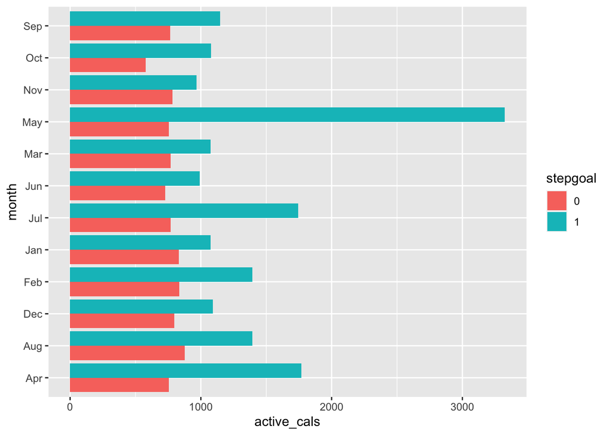

```r
ggplot(data = fitness_df, aes(x = month, y = active_cals)) +
  geom_col(aes(fill = stepgoal), position = "dodge") +
  coord_flip()
```

- `<FACET_FUNCTION>`: subplots
  - `<FACET_FUNCTION>` creates the ability to create subplots, showing more than one graph at a time.

### Importance of Color and Visual Perception

#### From: *Data Visualization: A Practical Introduction*

One thing that is overlooked about Data Visualization is the amount of science that goes into the smallest aspects, such as choosing colors for different variables, or how colors should fade on a scale. It is also important to remember people with color-blindness. If a plot is to be for everyone to learn, the colors must be so too.

In a categorically colored scatter plot, it is important to elect colors and shapes that are differential.

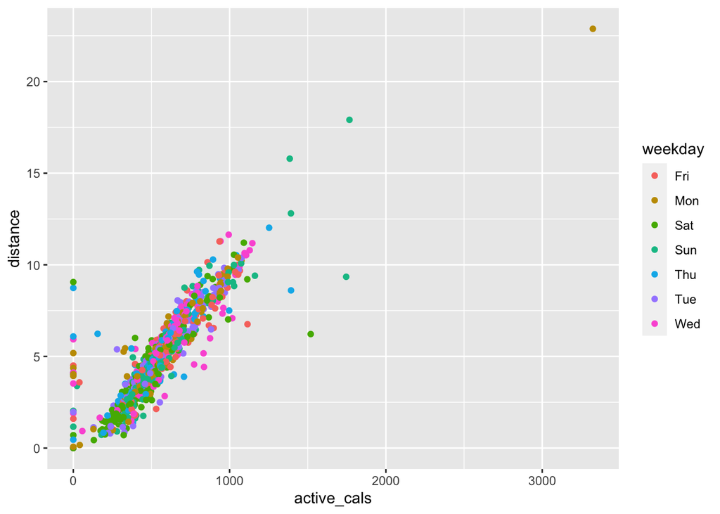

```r
ggplot(fitness_df, aes(x = active_cals, y = distance)) +
  geom_point(aes(color = weekday))
```

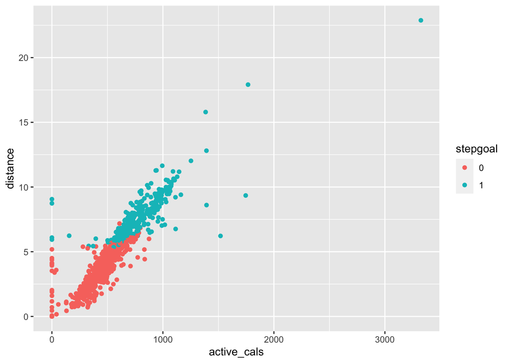

```r
ggplot(fitness_df, aes(x = active_cals, y = distance)) +
  geom_point(aes(color = stepgoal))
```

Different categorical variables will also change how the graph should be colored. We can see there is a much clearer line between the `stepgoal` and `weekday` variables,so the difference in the group is more obvious.

It is important to have your colors represent your data. For example, the random selection of colors featured to represent the days of the weeks would not be as applicable to a graph showing numerical differences with colors. Often, this is done with some sliding color scale.

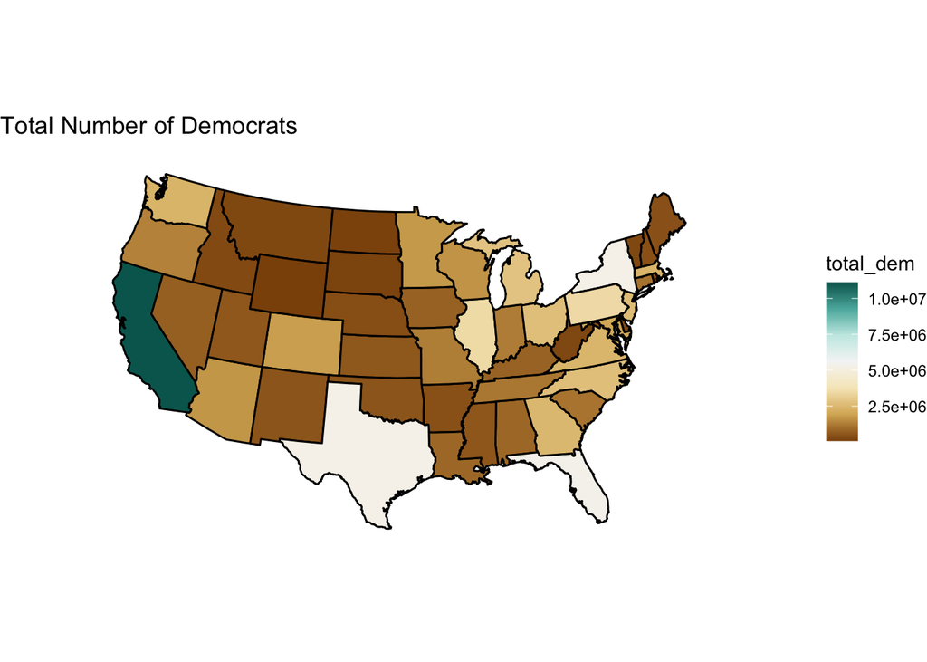

```r
ggplot(data = election_df, aes(x = long, y = lat, group = group)) +
  geom_polygon(aes(fill = total_dem), colour = "black") +
  coord_map(projection = "albers", lat0 = 39, lat1 = 45) +
  theme(axis.text = element_blank()) +
  theme_void() +
  scale_fill_distiller(type = "div", direction = 1) +
  labs(title = "Total Number of Democrats")
```

A plot like this uses a sliding scale to represent the data, because in this case the different points are not separated by clear categories, but rather a range of numbers.

These are the ways that color vitally important in Data Visualization. The science behind when colors look darker, how our brain perceives empty space depending on surroundings, all of these factors are taken into account by R when making the scales and color selections for plots.

### Data Ethics

#### From: *Chapter 3 - Data Feminism*

Data ethics are valuable when creating visualizations. Frequently, plots are made to reinforce a preconceived idea. This strategy leads to skewing of axes, points, colors, order of numbers, and many other small features to dupe the viewer. For example, often the time frame of the graph may not be initially evident, changing the first impression the audience has.

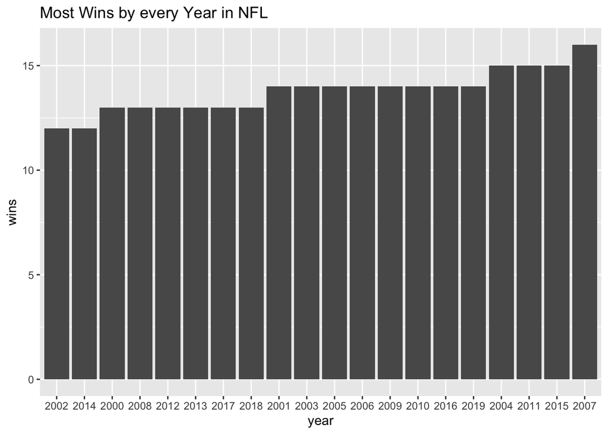

```r
ggplot(standings_top, aes(x = year, y = wins)) +
  geom_col() +
  labs(title = "Most Wins by every Year in NFL")
```

While this graph is rather straightforward, it appears to show some sort of positive growth. While the X-axis is time, it is not representing time sequentially. Tricks like this can trick people in to believing in growth and change trends which really are not there.

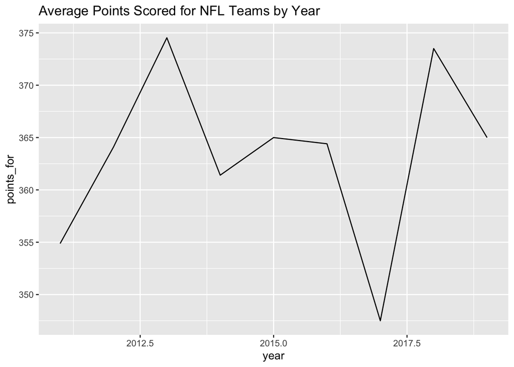

```r
ggplot(standings_ptsBIAS, aes(x = year, y = points_for)) +
  geom_line() +
  labs(title = "Average Points Scored for NFL Teams by Year")
```

When looking at this graph, the first interpretation is that from 2011 to 2019 the average NFL team only scored 10 more points. This is surprising for a league which is trending towards heavier promotion and advertising of offensive players, and a league which thrives off of high paced offense as an identity. Although it looks like the last 8 years have been stagnant for the NFL, the whole graph shows the story.

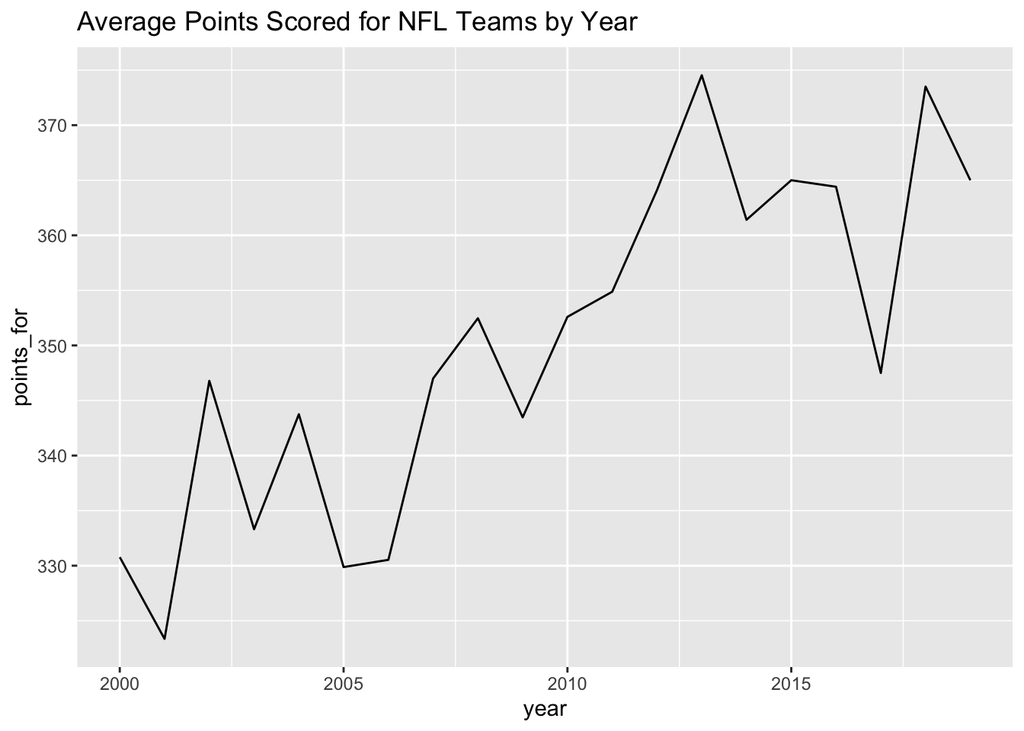

```r
ggplot(standings_pts, aes(x = year, y = points_for)) +
  geom_line() +
  labs(title = "Average Points Scored for NFL Teams by Year")
```

Clearly, when we look at the whole scope, the NFL is rapidly increasing as an offensive game. The first graph represented another example of Data Ethics which can be broken to lead narratives.

### Conclusion

Data Feminism wrote about the impact of graphs; how powerful visualizations can turn numbers into feelings. This is true in the sense of well made graphics, but also shows how dangerous of a tool it can be. Many of the plots we see today could be skewed to fit a certain world-view, that is why it is important to be vigilant before assuming the data to be fact.

## Section 2 - Mapping

### Introduction

Mapping is an important way to show data as it is truly representitive of areas and the data of said area. Statistical maps have become more popular as technology allows for creation of complex, engaging maps. In this section, we will look into making these maps and how we can optimize them for our liking.

### Mapping with `maps`

Using the `maps` tool to map is quite simple. All you need is a dataset that can provide an x value longitude and a y value latitude, and a `geom_polygon().` ggplot2 is built in with many maps already that we can access through `map_data().`

For this, I will be using ggplot2’s map_data() along with the `usdata` package. The variables will include `smoke`, the percentage of smokers, `homeowner`, the home ownership rate and `land_area`, the size area wise of the state.

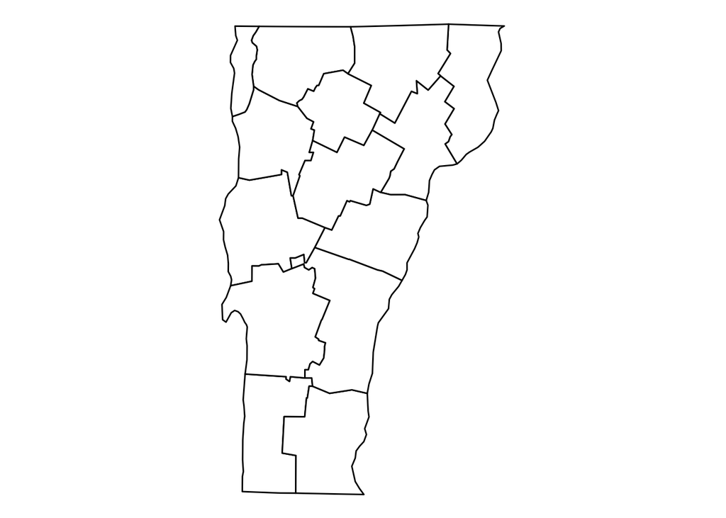

```r
library(tidyverse)
library(maps)
df <- ggplot2::map_data("county")

df <- df %>%
  filter(region == "vermont")


ggplot(data = df,
            mapping = aes(x = long, y = lat,
                          group = group)) +
  geom_polygon(fill = "white", colour = "black") +
  coord_map(projection = "albers", lat0 = 39, lat1 = 45) +
  theme(axis.text = element_blank()) +
  theme_void()
```

Just by filtering down the dfs provided by ggplot, I can get a map of all the counties in Vermont.

Now what is more important about using these features is displaying data within them.

```
## # A tibble: 51 × 24
##    state   abbr   fips pop2010 pop2000 homeownership multiunit income med_income
##    <fct>   <fct> <dbl>   <dbl>   <dbl>         <dbl>     <dbl>  <dbl>      <dbl>
##  1 Alabama AL        1  4.78e6  4.45e6          71.1      15.5  22984      42081
##  2 Alaska  AK        2  7.10e5  6.27e5          64.7      24.6  30726      66521
##  3 Arizona AZ        4  6.39e6  5.13e6          67.4      20.7  25680      50448
##  4 Arkans… AR        5  2.92e6  2.67e6          67.7      15.2  21274      39267
##  5 Califo… CA        6  3.73e7  3.39e7          57.4      30.7  29188      60883
##  6 Colora… CO        8  5.03e6  4.30e6          67.6      25.6  30151      56456
##  7 Connec… CT        9  3.57e6  3.41e6          69.2      34.6  36775      67740
##  8 Delawa… DE       10  8.98e5  7.84e5          73.6      17.7  29007      57599
##  9 Distri… DC       11  6.02e5  5.72e5          43.5      61.7  42078      58526
## 10 Florida FL       12  1.88e7  1.60e7          69.7      30    26551      47661
## # … with 41 more rows, and 15 more variables: poverty <dbl>, fed_spend <dbl>,
## #   land_area <dbl>, smoke <dbl>, murder <dbl>, robbery <dbl>,
## #   agg_assault <dbl>, larceny <dbl>, motor_theft <dbl>, soc_sec <dbl>,
## #   nuclear <dbl>, coal <dbl>, tr_deaths <dbl>, tr_deaths_no_alc <dbl>,
## #   unempl <dbl>
```

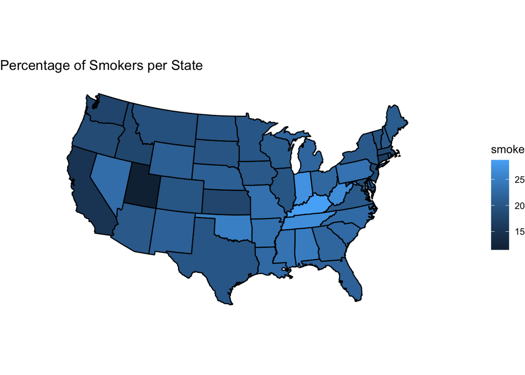

```r
ggplot(data = state_full,
            mapping = aes(x = long, y = lat,
                          group = group)) +
  geom_polygon(data = state_full, aes(fill = smoke), color = "black") +
  coord_map(projection = "albers", lat0 = 39, lat1 = 45) +
  theme(axis.text = element_blank()) +
  theme_void() +
  labs(title = "Percentage of Smokers per State")
```

Here, after using `long` and `lat` for x and y, we changed the fill of the geom_polygon figure in order to display our chosen statistic in each region. This should work for any region and any variable.

Just because it should work for any variable, does not mean that any variable is a fit to be used for a map.

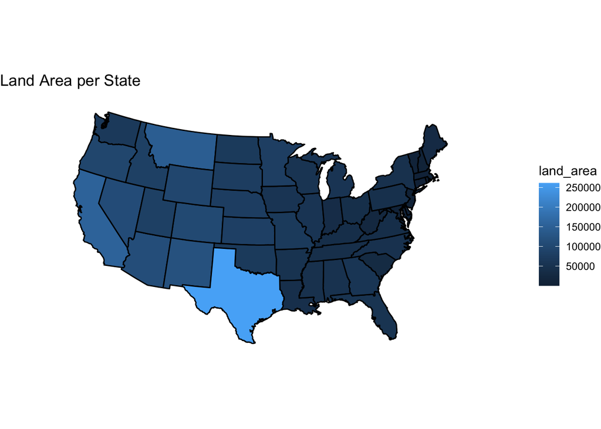

```r
ggplot(data = state_full,
            mapping = aes(x = long, y = lat,
                          group = group)) +
  geom_polygon(data = state_full, aes(fill = land_area), color = "black") +
  coord_map(projection = "albers", lat0 = 39, lat1 = 45) +
  theme(axis.text = element_blank()) +
  theme_void() +
  scale_color_viridis_b() +
  labs(title = "Land Area per State")
```

While there are no errors in the code, using the map to graph the size of a state is not very logical. We already can see the sizes of the states on the map, coloring them based on size does not add anything new to the map. While it is exciting to be able to project statistics onto maps, it is not always the best way to represent the data.

### Conclusion

Maps as a form of data visualization is a key part of now and the future of data. Finding new, more accessible and understandable ways to visualize data is always a positive development in the field of statistics. Maps are important because they simplify and make data tangible, they are more popular because there is no axes to interpret, and no complicated statistical elements found in regular graphs.

## Section 3 - Variability

### Introduction

```r
airline_safety <- read_csv("~/SLU/SP2022/Stat-4005/STAT4005/data/airline-safety.csv")
```

### Incorporating Data Variability in Graphs

One reason incorporating variability is important is to prevent outliers from skewing the way the data is visualized. One example of this would be a chart showing the mean value for incidents.

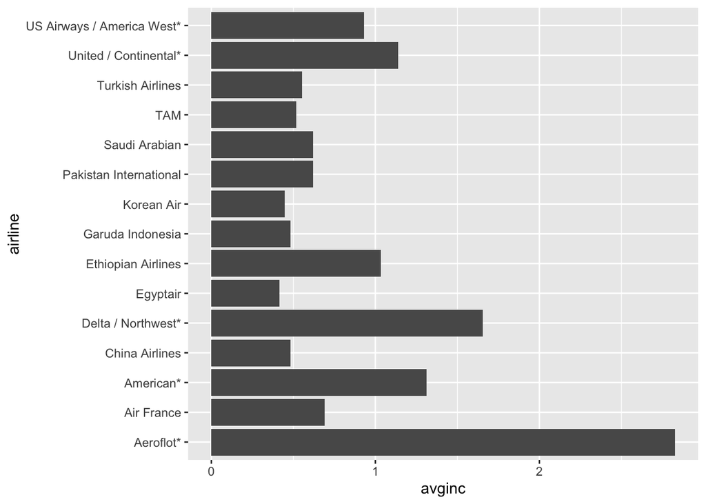

```r
airline_safety <- airline_safety %>%
  group_by(airline) %>%
  mutate(totalfatalities = sum(c(`fatalities 1985_1999`,`fatalities 2000_2014`))) %>%
  mutate(totalincidents = sum(c(`incidents 1985_1999`,`incidents 2000_2014`)))

airline_safety <- airline_safety %>%
  group_by(airline)%>%
  mutate(avginc = totalincidents / 29)%>%
  mutate(avgfat = totalfatalities / 29)

airline_safety <- airline_safety %>%
  filter(avginc > .4)

ggplot(data = airline_safety, aes(x = avginc, y = airline)) +
  geom_col()
```

This graph here shows the top 15 highest amount of average annual incidents for airlines. Based on the graph, it appears that Aeroflot has more than an incident every year. But if you re-graph it to show both total incidents and the average incident number…

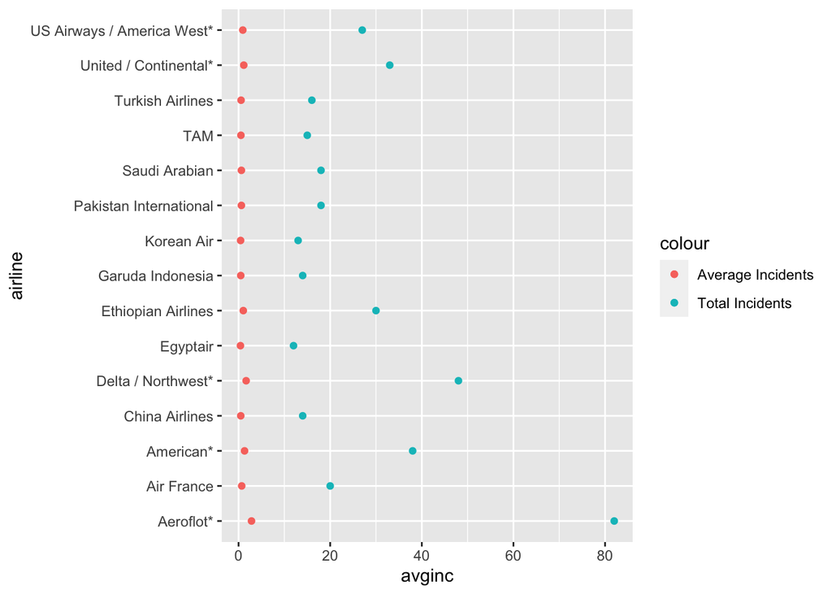

```r
ggplot(data = airline_safety) +
  geom_point(aes(x = avginc, y = airline, color = "Average Incidents")) +
  geom_point(aes(x = totalincidents, y = airline, color ="Total Incidents"))
```

### Conclusion

From this, we can see that we never get the full story of the data just from the average, or one single summary statistic. It is important to look at the range of values that the data set produces before ignoring important data points that you cannot see.

## Section 4 - Shiny

### Introduction to Shiny

Shiny is an essential part to creating advanced data visualizations in R. Shiny allows you to create interactive graphs. Frequently this is select which variables to graph, hover over to see which point means which, or type in a certain input in order to continue on the graph.

We will be using basic shiny to create a static graph, then advance further and create a reactive graph which changes with the user’s input.

```r
library(shiny)
ui <- fluidPage(
  textInput("number", "Enter your favorite number"),
  textOutput("favorite")
)
server <- function(input, output, session) {
  output$favorite <- renderText({
  paste0("Your favorite number is ", input$number)
})

}
shinyApp(ui, server)
```

Shiny applications not supported in static R Markdown documents

This is a basic Shiny app to show how one can write interactively in Shiny. As you can see, is a UI and a server. The server is where all of the work is done, the calculations, addressing the user changes, creating objects to print. The UI serves as where to type which console objects should appear in the user interface,

### Introduction to Reactivity

Reactivity means that the dataset featured in the Shiny app has to be changed as the user requests it. As options are presented, the user can create a new graph without opening or closing the Shiny window.

```r
gv_df <- read_csv("~/SLU/SP2022/Stat-4005/STAT4005/data/gun_violence_us.csv")

library(shiny)

var_choices <- names(gv_df$region)


ui <- fluidPage(
  sidebarLayout(sidebarPanel(
    selectizeInput("countrychoice",
                   label = "Choose a Country",
                   choices = levels(factor(gv_df$region)),
    mainPanel(plotOutput("scattergraph"))
  ),
    sidebarLayout(sidebarPanel(
    radioButtons("regionchoice",
                   label = "Choose a Type of Alcohol",
                   choices = var_choices)),
    mainPanel(plotOutput("histograph"))
  )
)

server <- function(input, output, session) {

  df_sub <- reactive({
    gv_df %>% filter(region == input$region)
  })

  scatter_plot <- reactive({
    ggplot(alcohol_df, aes(x = ownership_rate, y = mortality_rate)) +
      geom_point(colour = "black", fill = "white", bins = 15) +
      geom_point(data = df_sub(), aes(x = ownership_rate, y = mortality_rate,
                                      color = region)) +
      geom_text(data = df_sub(), aes(label = country), hjust=0, vjust=0)
  })


  output$scattergraph <- renderPlot({
    scatter_plot()
  })


}

shinyApp(ui, server)
```

[output not shown]

### Conclusion

In all, Shiny presents users with the option to create graphs with much more options than regular ggplot graphs. Shiny allows you to change all of the elements of the graph instantly, create custom graphs instantly. Shiny also allows for statisticians to create cool applications to share with students, other scholars, or the general public.